# PSTAT 174/274 Spring 2023: Homework 5

### Question 2

Choose a dataset that you will be interested to analyze for your class final project. URLs of time series libraries are posted on Gaucho Space. Provide the following information about the project:

1. Data set description: briefly describe the data set you plan to use in your project.  
   I want to improve on my final project from PSTAT 231. In that project, my dataset was 2 combined time series of the number of deaths, cases, and vaccinations of the US population per month during the COVID pandemic. It also had the daily historic data and it was all categorized by county and by state within the US. For this project, I will use the daily time series of the smoothed new cases and smoothed new deaths for the entire world to see when the fatality rate for covid will be as low as it is from the flu. The data was obtained from: https://ourworldindata.org/mortality-risk-covid
2. Motivation and objectives: briefly explain why this data set is interesting or important. Provide a clear description of the problem you plan to address using this dataset (for example to forecast).  
   On my previous project, my goal was to predict the future number of cases and deaths caused by COVID. Now that there are so many lesser strains and variants of COVID, I do not believe that the virus will go away any time soon. I predict that the cases and deaths will continuously decrease over time until cases of COVID become far less severe, and then eventually, the complete vaccination of the entire the majority of the world population will relegate COVID to a seasonal sickness such as the flu. I want to see how long it will take until the amount of cases and deaths caused by covid resembles those caused by the flu.
3. Plot and examine the main features of the graph, checking in particular whether there is (i) a trend; (ii) a seasonal component, (iii) any apparent sharp changes in behavior. Explain in detail.

```r
covid <- read.csv("owid-covid-data 2.csv")

covid[(is.na(covid))]<-0

covid <- covid %>%
  group_by(date) %>%
  summarise(across(c(total_cases, new_cases, new_cases_smoothed, total_deaths, new_deaths, new_deaths_smoothed), sum))

covid["Smoothed_New_Case_Fatality_Rate"] = NA

for(i in 1:1225){
  covid$Smoothed_New_Case_Fatality_Rate[i] = covid$new_deaths_smoothed[i] / covid$new_cases_smoothed[i]}

covid <- covid[346:1225,]

Mortality = ts(covid$Smoothed_New_Case_Fatality_Rate)
frequency(Mortality)
```

```
## [1] 1
```

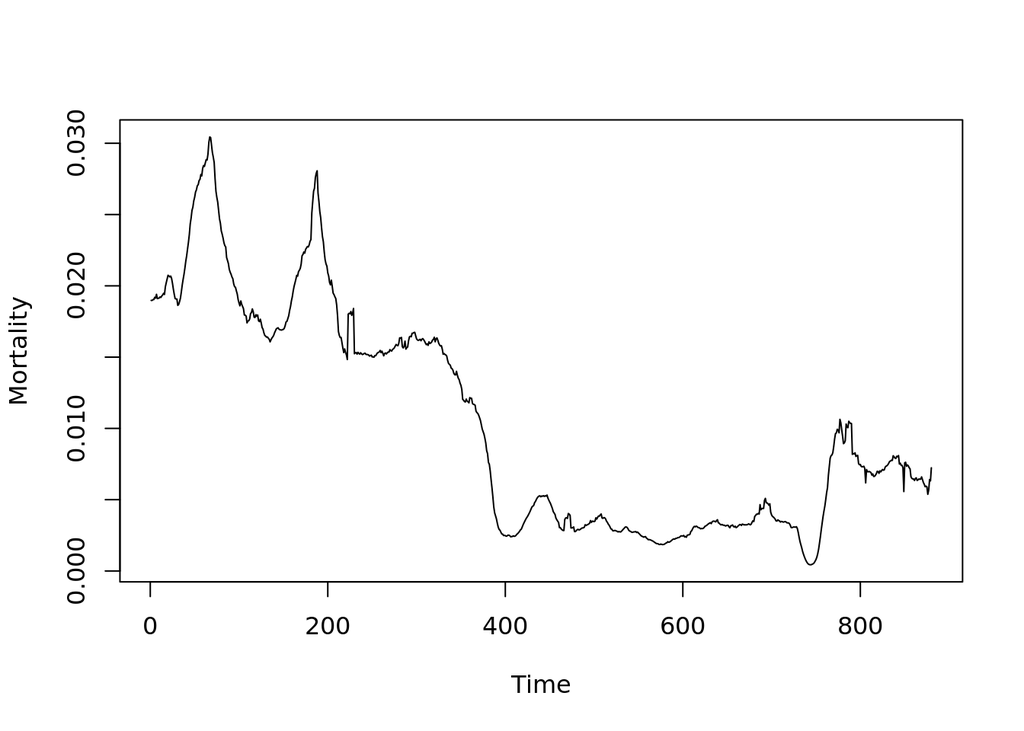

```r
plot.ts(Mortality)
```

```r
Mortality_acf1 = acf2(Mortality)
```

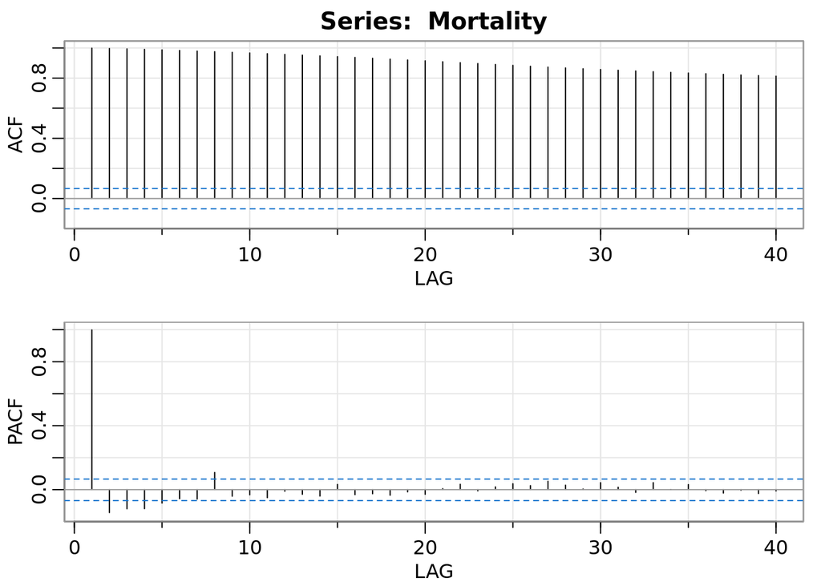

```r
var(Mortality)
```

```
## [1] 6.025961e-05
```

There was a sharp change in behavior for my original dataset. This was the time during the pandemic when the vaccine had not been created yet. It was decided that only the daily cases and deaths after the release of the vaccine should be included within the model.

It is too early to tell if there will be a seasonal component since there has only been data for 2.5 years. There does appear to be a negative trend which makes sense because the fatality rate of those who catch covid will continue to decrease as more research is done to create more effective vaccines.

4. Use any necessary transformations to get stationary series. Give a detailed explanation to justify your choice of a particular procedure. If you have used transformation, justify why. If you have used differencing, what lag did you use? Why? Is your series stationary now?

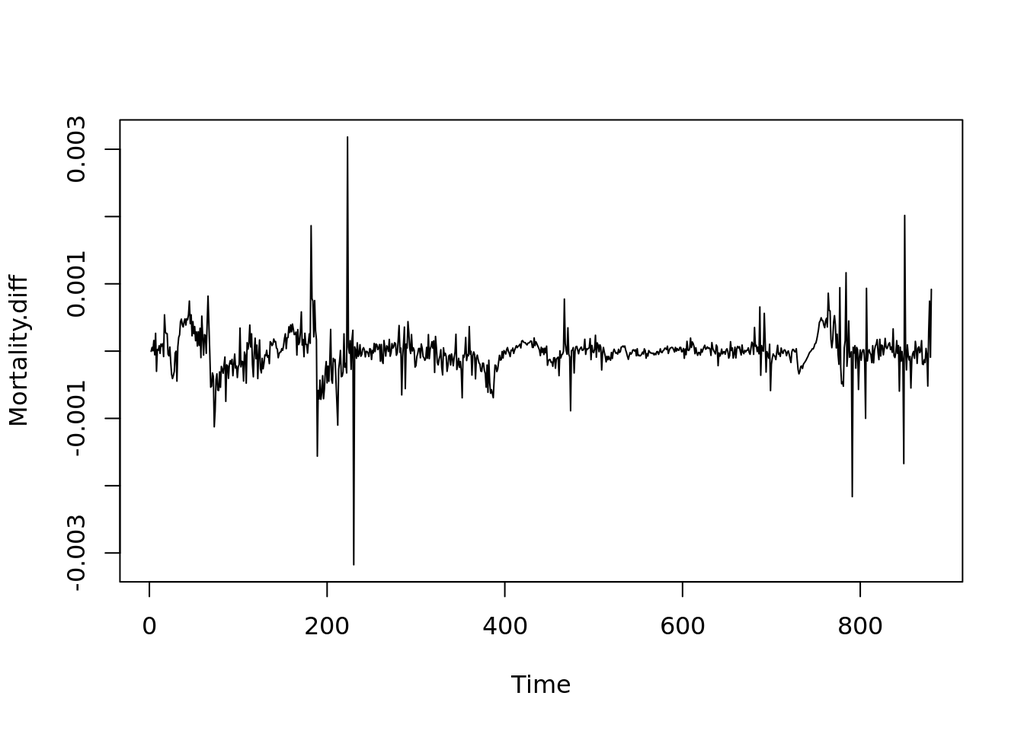

```r
Mortality.diff = diff(Mortality, 1)
plot.ts(Mortality.diff)
```

```r
Mortality.diff_acf1 = acf2(Mortality.diff)
```

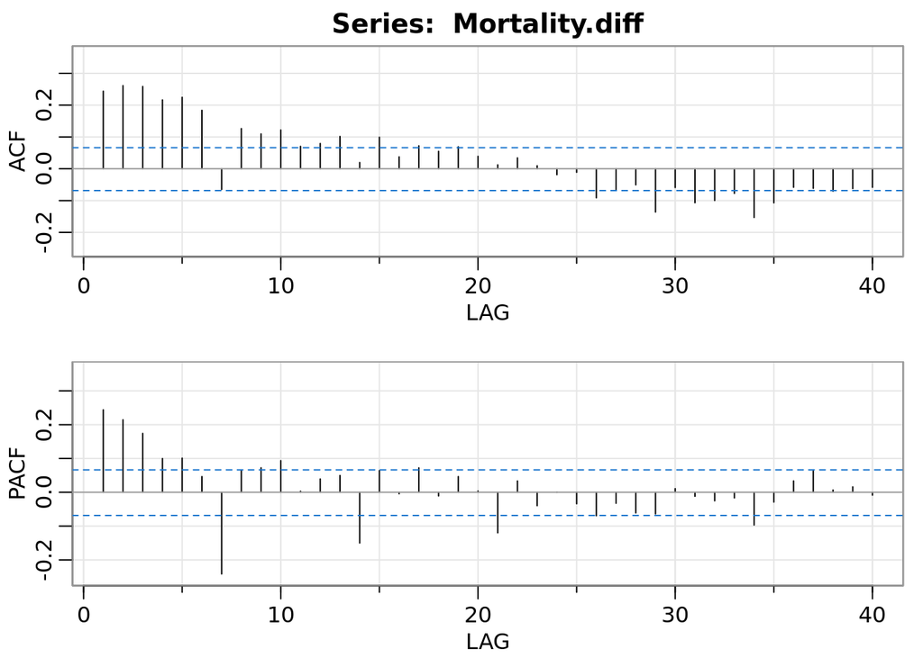

```r
var(Mortality.diff)
```

```
## [1] 1.019611e-07
```

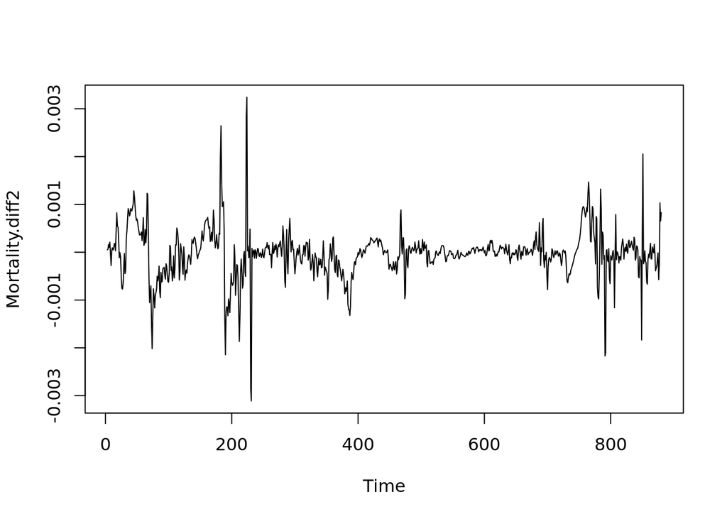

```r
Mortality.diff2 = diff(Mortality, 2)
plot.ts(Mortality.diff2)
```

```r
Mortality_acf2 = acf2(Mortality.diff2)
```

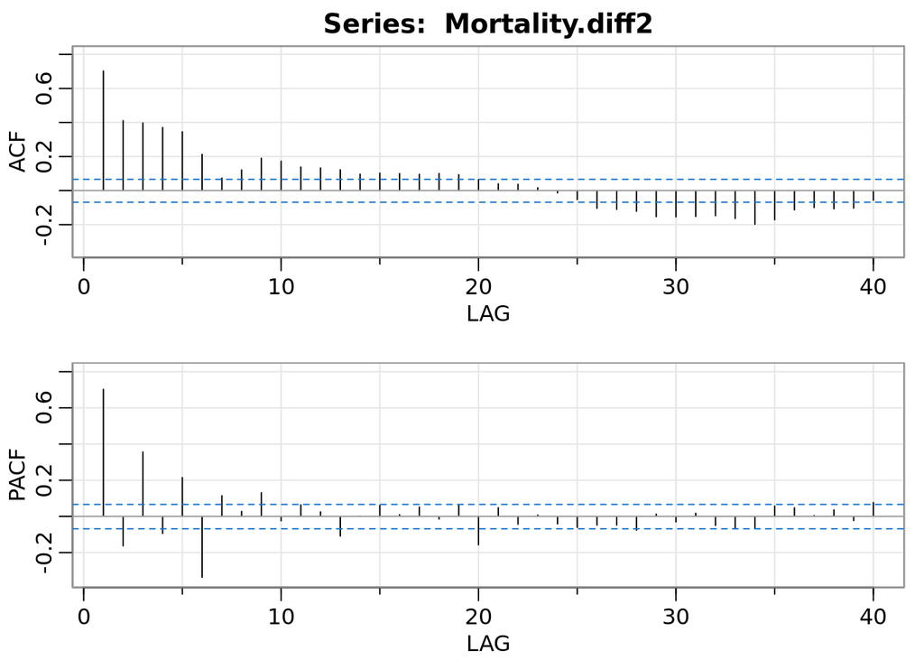

```r
var(Mortality.diff2)
```

```
## [1] 2.529567e-07
```

```r
# Diff = 1
var(Mortality.diff) < var(Mortality.diff2)
```

```
## [1] TRUE
```

Testing was done to see if differencing lead to a smaller variance. While the first difference decreased the variance, the second difference increased it, so it was decided that there would be a difference at lag 1.

5. Plot and analyze the ACF and PACF to preliminary identify your model(s): Plot ACF/PACF. What model(s) do they suggest? Explain your choice of p and q here. If your dataset does not work for you, please comment why. For example, the dataset is too short, exhibits change of behavior, does not look like a second-order process, etc. You might review slide 47 of Week 4, Lecture 8. Note that you may change the project dataset in the future. This question is designed to help you start planning your the project. Please include plots of corresponding theoretical acfs and the corresponding R code.

```r
ar1 = ar(Mortality.diff, aic = FALSE, method="mle") # 12
ar2 = ar(Mortality.diff, aic = FALSE, method="yw") # 29
ar3 = ar(Mortality.diff, aic = TRUE, method="mle") # 10
ar4 = ar(Mortality.diff, aic = TRUE, order.max = 12, method="yw") # 10

ar1$var.pred
```

```
## [1] 7.96277e-08
```

```r
ar2$var.pred
```

```
## [1] 7.730354e-08
```

```r
ar3$var.pred
```

```
## [1] 7.976192e-08
```

```r
ar4$var.pred
```

```
## [1] 8.113891e-08
```

```r
ar1$aic
```

```
## 12
##  0
```

```r
ar2$aic
```

```
##           0           1           2           3           4           5
## 215.4330905 163.5268653 124.1354670  99.0676824  92.2910659  85.2865172
##           6           7           8           9          10          11
##  85.3896819  34.5069461  32.9142375  30.2829726  24.5757512  26.5669340
##          12          13          14          15          16          17
##  27.2068093  27.0332938   9.0077445   7.3737221   9.3562484   6.7596209
##          18          19          20          21          22          23
##   8.6558351   8.7541054  10.7420696   0.0000000   1.0184367   1.6365298
##          24          25          26          27          28          29
##   3.6365276   4.6240310   2.3684639   3.4392233   2.1517468   0.5575258
```

```r
ar3$aic
```

```
##          0          1          2          3          4          5          6
## 193.871468 141.483780 102.000133  76.396297  69.336277  62.415403  62.654034
##          7          8          9         10         11         12
##   9.721402   8.104367   5.676890   0.000000   1.985277   2.545614
```

```r
ar4$aic
```

```
##          0          1          2          3          4          5          6
## 190.857339 138.951114  99.559716  74.491931  67.715315  60.710766  60.813931
##          7          8          9         10         11         12
##   9.931195   8.338486   5.707221   0.000000   1.991183   2.631058
```

```r
source("innovations.R")

acvf = acf(Mortality.diff, plot=FALSE, lag.max = length(Mortality.diff))$acf[,1,1] * var(Mortality.diff)
m = length(acvf)
lh.ia = innovations.algorithm(m+1, acvf)
lh.ia$thetas[9,1:9] # Preliminary estimates of coefficients for MA(9)
```

```
## [1]  0.1441523  0.2007446  0.1917800  0.1738665  0.2078018  0.1744562 -0.1257057
## [8]  0.1059287  0.1096143
```

```r
lh.ia$thetas[10,1:10] # Preliminary estimates of coefficients for MA(10)
```

```
##  [1]  0.13737924  0.19414125  0.21975944  0.17095596  0.20067177  0.16539717
##  [7] -0.14440330  0.08829378  0.08494162  0.12187825
```

```r
lh.ia$thetas[11,1:11] # Preliminary estimates of coefficients for MA(11)
```

```
##  [1]  0.13708332  0.19298318  0.21784569  0.18155848  0.20067146  0.16445592
##  [7] -0.14698748  0.08633033  0.07929917  0.11131375  0.07046475
```

```r
lh.ia$thetas[12,1:12] # Preliminary estimates of coefficients for MA(12)
```

```
##  [1]  0.13695878  0.18926873  0.21368188  0.17690076  0.22102382  0.16302501
##  [7] -0.15086298  0.08402203  0.07380800  0.10179423  0.05431461  0.07946496
```

```r
arima1 <- auto.arima(Mortality.diff, start.p = 0, start.q = 0, start.P = 0, start.Q = 0, stationary=TRUE, seasonal = TRUE, trace = TRUE) # 5,0,0
```

```
##
##  Fitting models using approximations to speed things up...
##
##  ARIMA(0,0,0) with non-zero mean : -11653.23
##  ARIMA(0,0,0) with non-zero mean : -11653.23
##  ARIMA(1,0,0) with non-zero mean : -11704.67
##  ARIMA(0,0,1) with non-zero mean : -11689.7
##  ARIMA(0,0,0) with zero mean     : -11653.7
##  ARIMA(2,0,0) with non-zero mean : -11743.27
##  ARIMA(3,0,0) with non-zero mean : -11767.95
##  ARIMA(4,0,0) with non-zero mean : -11774.28
##  ARIMA(5,0,0) with non-zero mean : -11780.29
##  ARIMA(5,0,1) with non-zero mean : -11778.53
##  ARIMA(4,0,1) with non-zero mean : -11776.79
##  ARIMA(5,0,0) with zero mean     : -11782.12
##  ARIMA(4,0,0) with zero mean     : -11776.04
##  ARIMA(5,0,1) with zero mean     : -11780.37
##  ARIMA(4,0,1) with zero mean     : -11778.59
##
##  Now re-fitting the best model(s) without approximations...
##
##  ARIMA(5,0,0) with zero mean     : -11786.42
##
##  Best model: ARIMA(5,0,0) with zero mean
```

```r
fit.ar1 <- arima(Mortality.diff, order=c(5,0,0))
fit.ar2 <- arima(Mortality.diff, order=c(10,0,0))
fit.ar3 <- arima(Mortality.diff, order=c(12,0,0))
fit.ar4 <- arima(Mortality.diff, order=c(29,0,0))

fit.ma5 <- arima(Mortality.diff, order=c(0,0,9))
fit.ma6 <- arima(Mortality.diff, order=c(0,0,10))
fit.ma7 <- arima(Mortality.diff, order=c(0,0,11))
fit.ma8 <- arima(Mortality.diff, order=c(0,0,12))

fit.arma9 <- arima(Mortality.diff, order=c(5,0,9)) # 12/14 0.05 < s.e. < 0.21
fit.arma10 <- arima(Mortality.diff, order=c(5,0,10)) # NAN produced
fit.arma11 <- arima(Mortality.diff, order=c(5,0,11)) # all 0.07 < s.e. < 0.77
fit.arma12 <- arima(Mortality.diff, order=c(5,0,12)) # 13/17 0.05 < s.e. < 0.837
fit.arma13 <- arima(Mortality.diff, order=c(10,0,9)) # NAN produced
fit.arma14 <- arima(Mortality.diff, order=c(10,0,10)) # 18/20  0.05 < s.e. < 0.099
fit.arma15 <- arima(Mortality.diff, order=c(10,0,11)) # all 0.97 < s.e. < 0.32
fit.arma16 <- arima(Mortality.diff, order=c(10,0,12)) # all 0.12 < s.e. < 0.61

fit.arma17 <- arima(Mortality.diff, order=c(12,0,9)) # all 0.05 < s.e. < 0.60
fit.arma18 <- arima(Mortality.diff, order=c(12,0,10)) # NAN produced
fit.arma19 <- arima(Mortality.diff, order=c(12,0,11)) # NAN produced
#fit.arma20 <- arima(Mortality.diff, order=c(12,0,12)) # all 0.09 < s.e. < 0.37
#fit.arma21 <- arima(Mortality.diff, order=c(29,0,9)) # NAN produced
#fit.arma22 <- arima(Mortality.diff, order=c(29,0,10)) # NAN produced
# fit.arma23 <- arima(Mortality.diff, order=c(29,0,11)) # NAN produced
# fit.arma24 <- arima(Mortality.diff, order=c(29,0,12)) # NAN produced

# STATIONARY
fit.arma25_10 <- arima(Mortality.diff, order=c(25,0,10)) # NAN produced
# STATIONARY w/out NANs for s.e.
fit.arma25_9 <- arima(Mortality.diff, order=c(25,0,9)) # NAN produced

Data <- data.frame(c(AICc(fit.ar1),
AICc(fit.ar2),
AICc(fit.ar3),
AICc(fit.ar4),
AICc(fit.ma5),
AICc(fit.ma6),
AICc(fit.ma7),
AICc(fit.ma8),
AICc(fit.arma9),
AICc(fit.arma10),
AICc(fit.arma11),
AICc(fit.arma12),
AICc(fit.arma13),
AICc(fit.arma14),
AICc(fit.arma15),
AICc(fit.arma16),
AICc(fit.arma17),
AICc(fit.arma18),
AICc(fit.arma19),
#AICc(fit.arma20),
#AICc(fit.arma21),
#AICc(fit.arma22),
AICc(fit.arma25_10),
AICc(fit.arma25_9)))

rownames(Data) <- c("AR(5)", "AR(10)", "AR(12)", "AR(29)", "MA(9)", "MA(10)", "MA(11)", "MA(12)", "ARMA(5,9)", "ARMA(5,10)", "ARMA(5,11)", "ARMA(5,12)", "ARMA(10,9)", "ARMA(10,10)", "ARMA(10,11)", "ARMA(10,12)", "ARMA(12,9)", "ARMA(12,10)", "ARMA(12,11)", "ARMA(25,10)", "ARMA(25,9)")
colnames(Data) <- c("AICc")

Data["Lowest AICc"] <- as.integer(rank(Data$AICc))
Data
```

```
##                  AICc Lowest AICc
## AR(5)       -11784.57          21
## AR(10)      -11846.78          19
## AR(12)      -11844.10          20
## AR(29)      -11871.48          18
## MA(9)       -11877.45          17
## MA(10)      -11880.70          12
## MA(11)      -11880.18          14
## MA(12)      -11878.96          16
## ARMA(5,9)   -11880.98          11
## ARMA(5,10)  -11882.17           8
## ARMA(5,11)  -11879.84          15
## ARMA(5,12)  -11889.13           2
## ARMA(10,9)  -11883.13           6
## ARMA(10,10) -11890.73           1
## ARMA(10,11) -11887.17           3
## ARMA(10,12) -11884.52           4
## ARMA(12,9)  -11880.47          13
## ARMA(12,10) -11881.67          10
## ARMA(12,11) -11881.86           9
## ARMA(25,10) -11882.22           7
## ARMA(25,9)  -11883.27           5
```

```r
acf1 = acf2(fit.ar1$residuals)
```

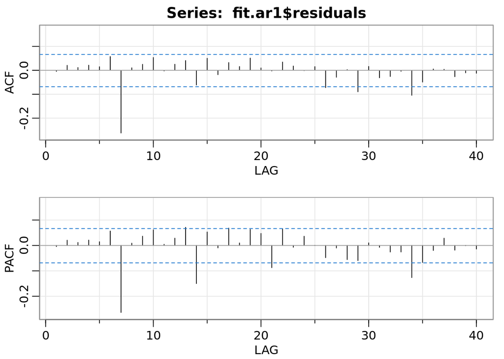

```r
acf2 = acf2(fit.ar2$residuals)
```

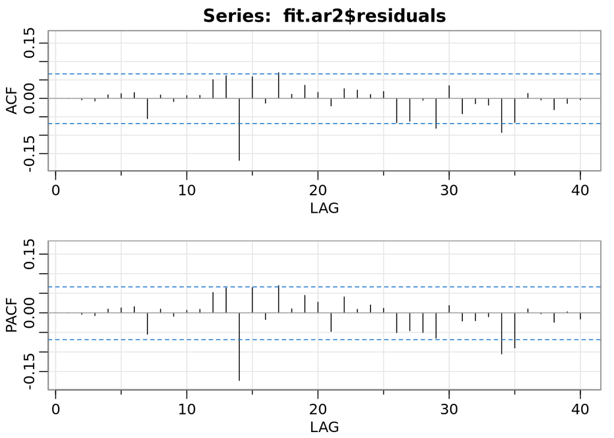

```r
acf3 = acf2(fit.ar3$residuals)
```

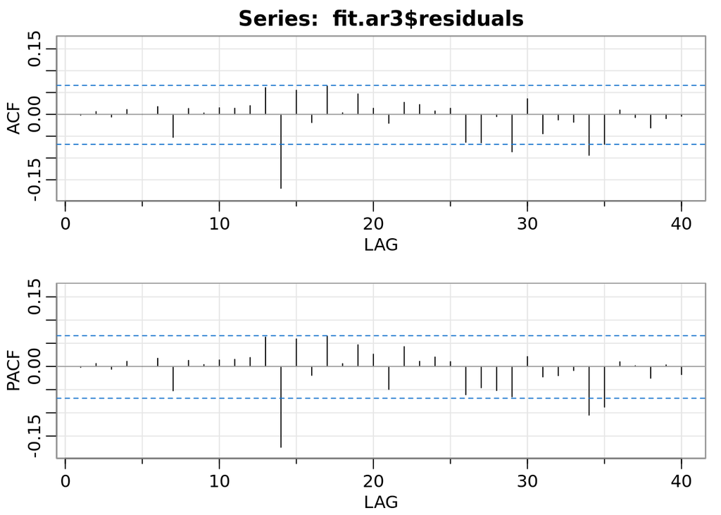

```r
acf4 = acf2(fit.ar4$residuals)
```

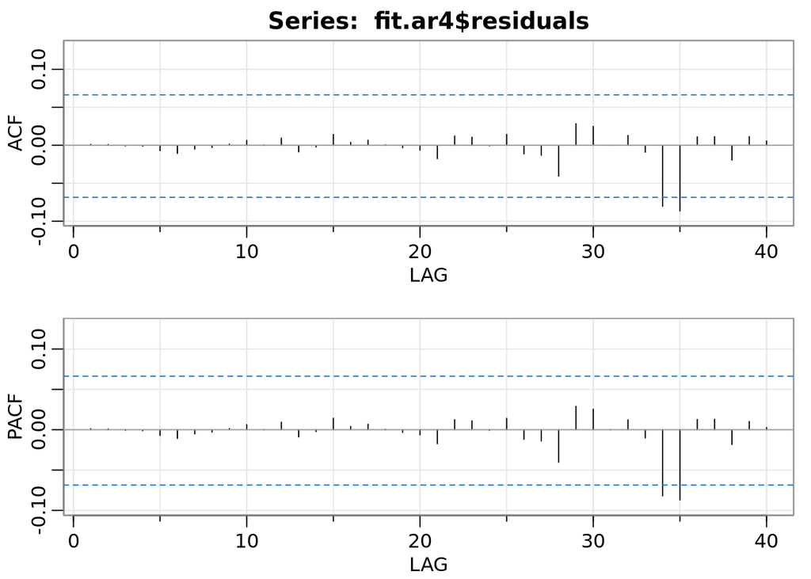

```r
acf5 = acf2(fit.ma5$residuals)
```

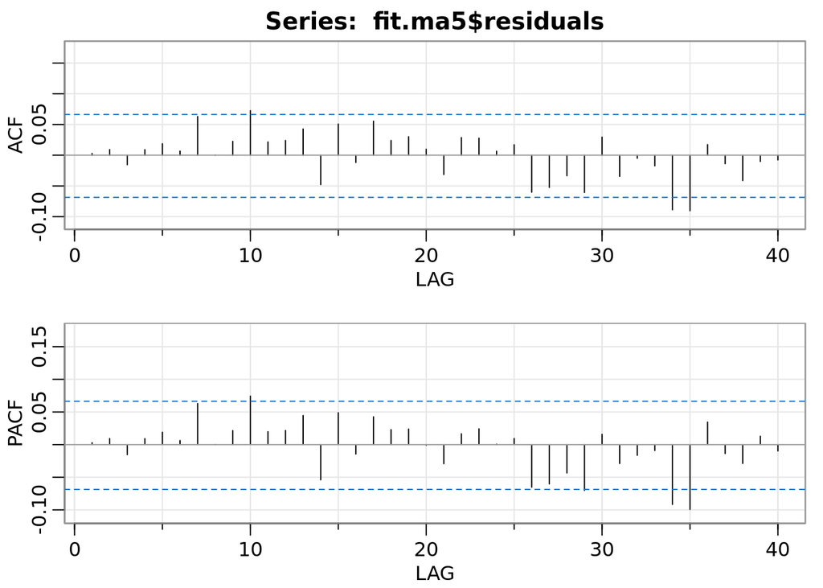

```r
acf6 = acf2(fit.ma6$residuals)
```

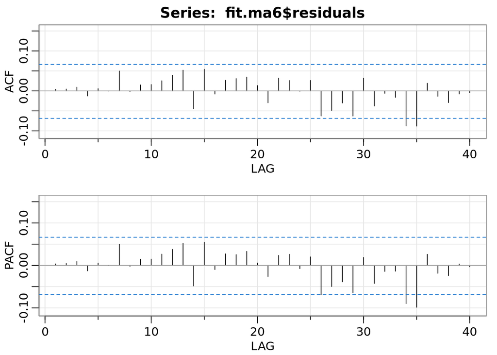

```r
acf7 = acf2(fit.ma7$residuals)
```

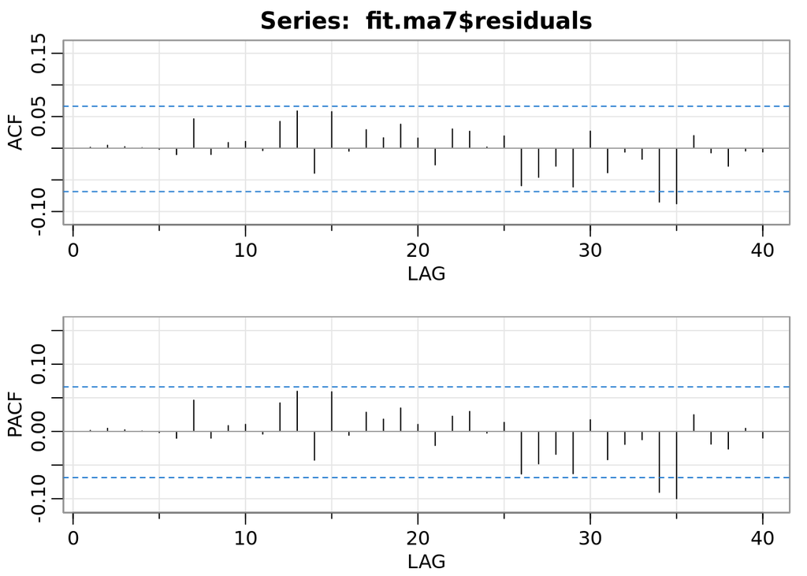

```r
acf8 = acf2(fit.ma8$residuals)
```

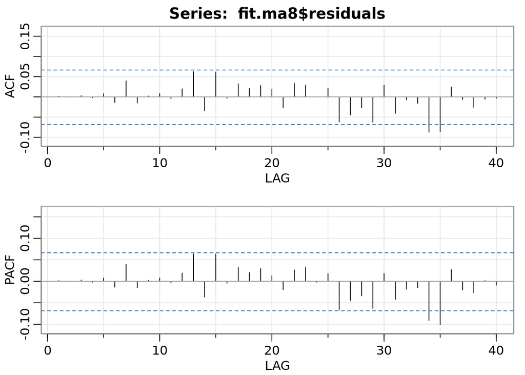

```r
acf9 = acf2(fit.arma9$residuals)
```

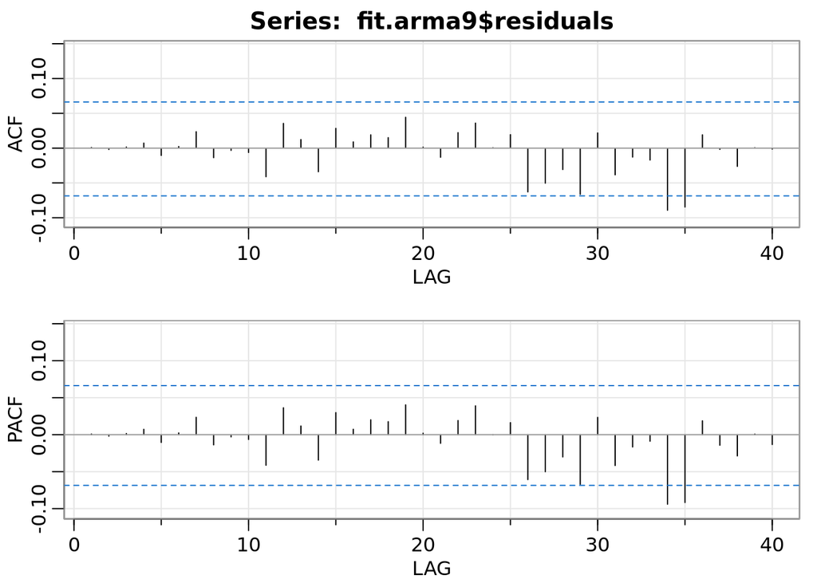

```r
acf10 = acf2(fit.arma10$residuals)
```

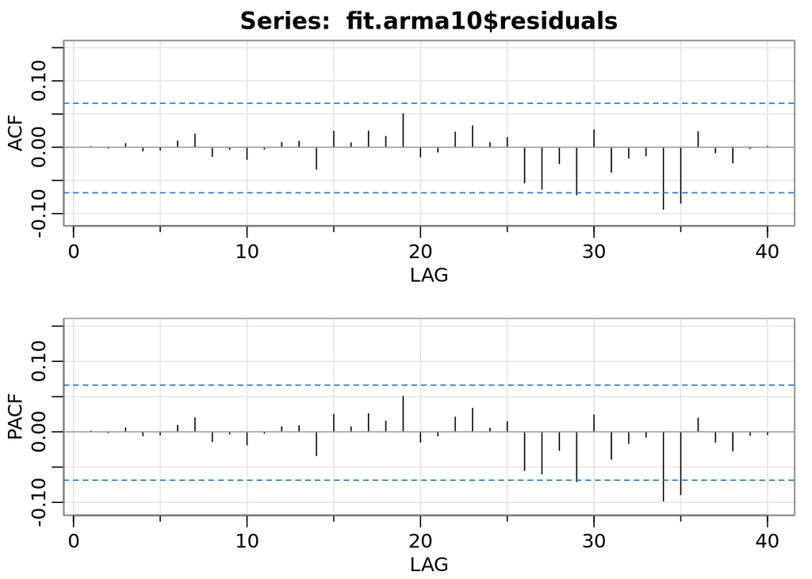

```r
acf11 = acf2(fit.arma11$residuals)
```

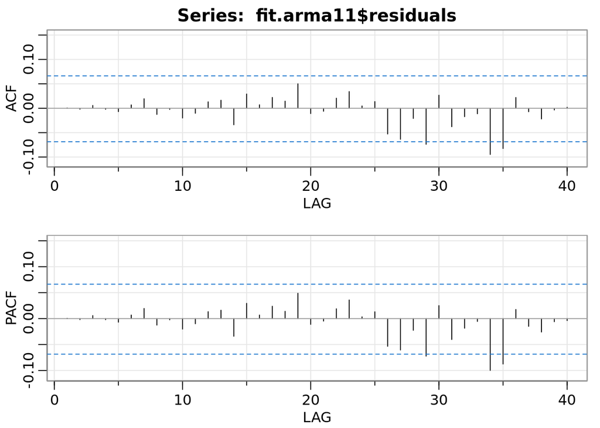

```r
acf12 = acf2(fit.arma12$residuals)
```

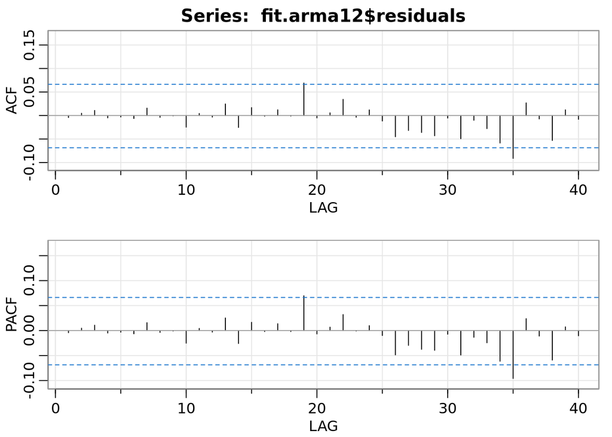

```r
acf13 = acf2(fit.arma13$residuals)
```

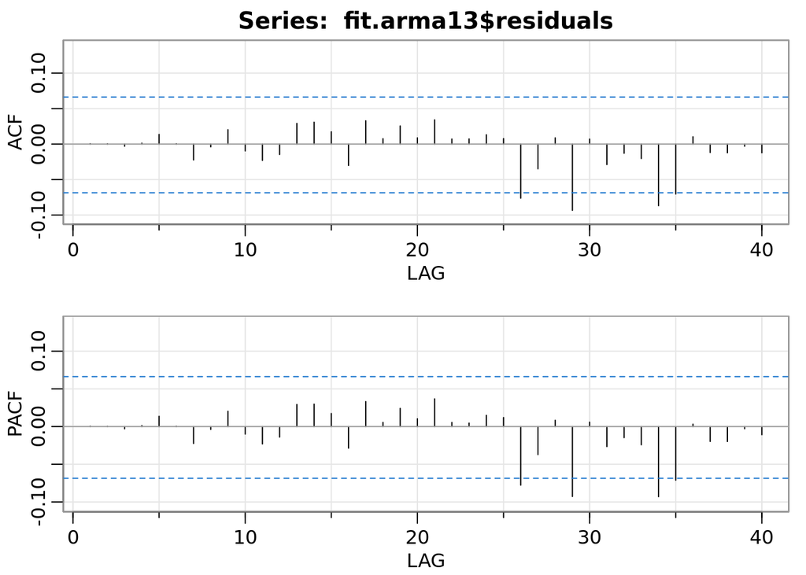

```r
acf14 = acf2(fit.arma14$residuals)
```

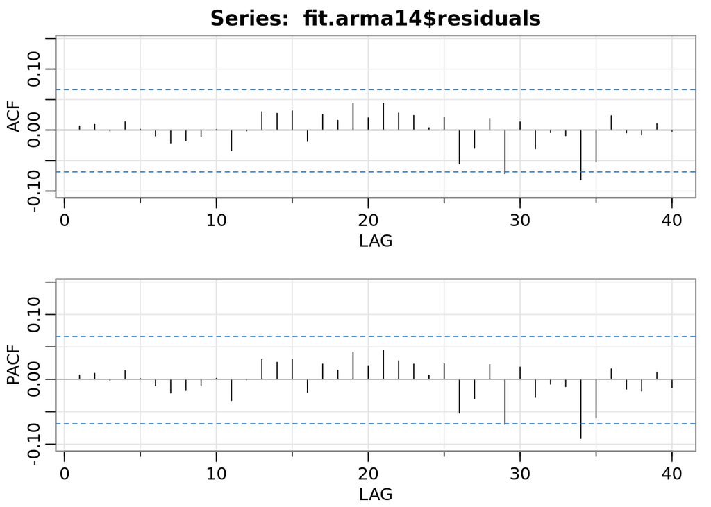

```r
acf15 = acf2(fit.arma15$residuals)
```

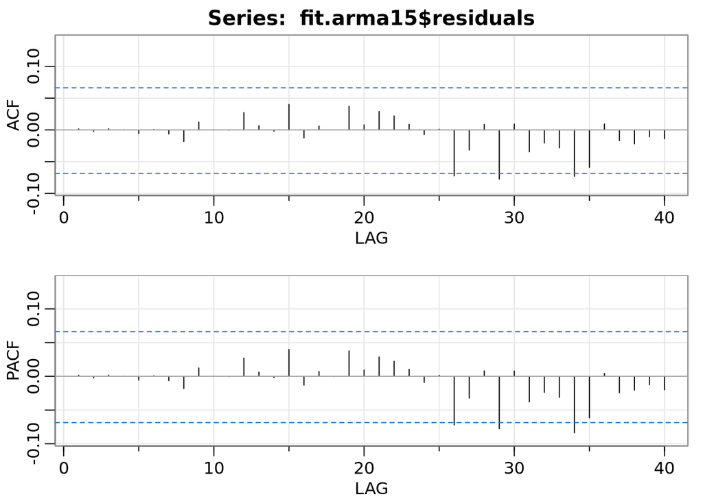

```r
acf16 = acf2(fit.arma16$residuals)
```

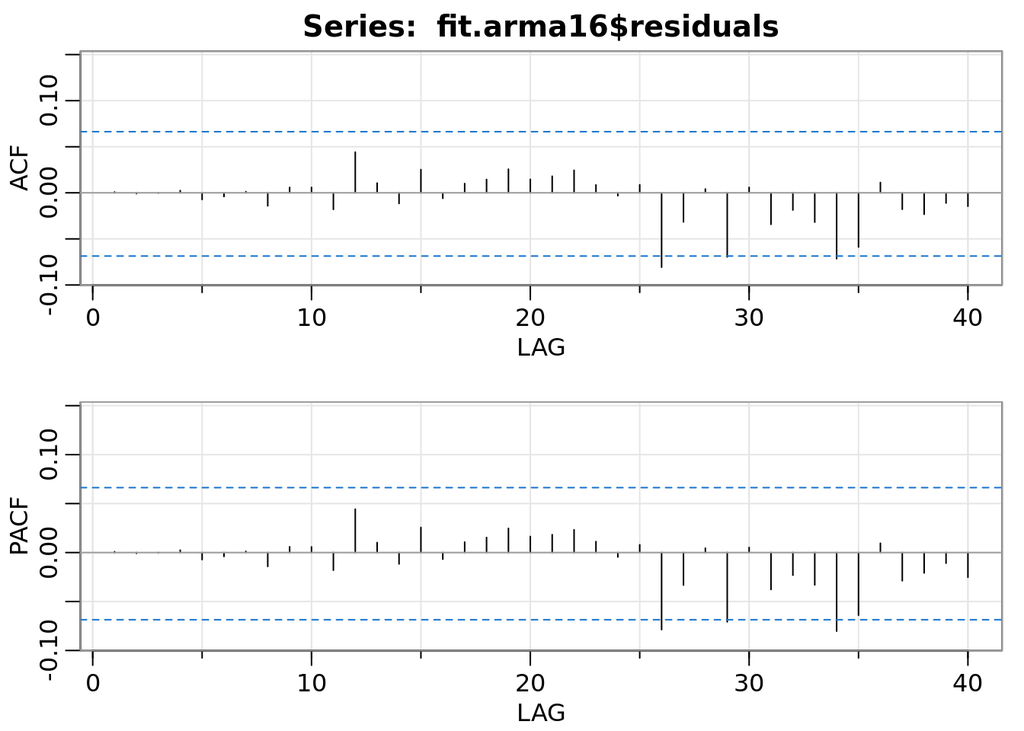

```r
acf17 = acf2(fit.arma17$residuals)
```

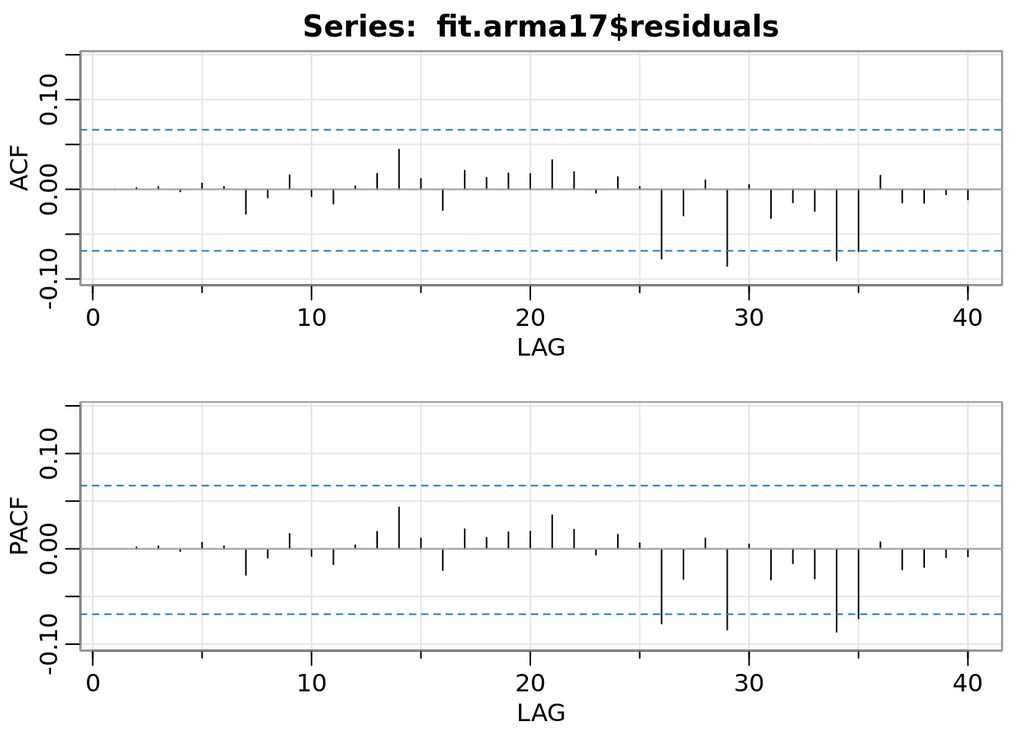

```r
acf18 = acf2(fit.arma18$residuals)
```

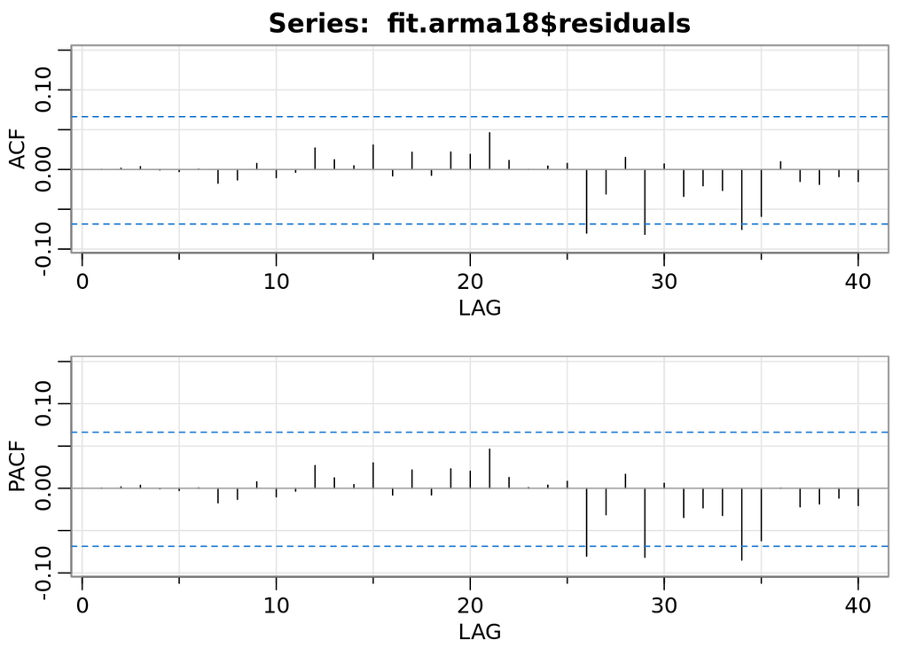

```r
acf19 = acf2(fit.arma19$residuals)
```

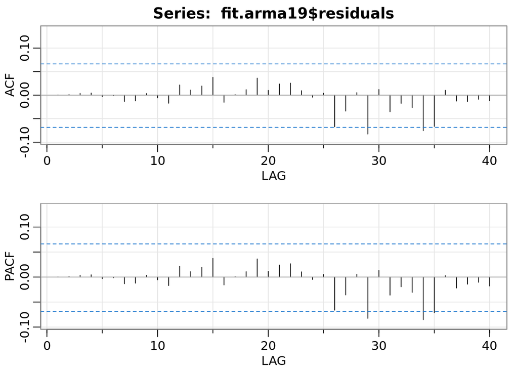

```r
#acf20 = acf2(fit.arma20$residuals)
#acf21 = acf2(fit.arma21$residuals)
#acf22 = acf2(fit.arma22$residuals)
acf23 = acf2(fit.arma25_10$residuals)
```

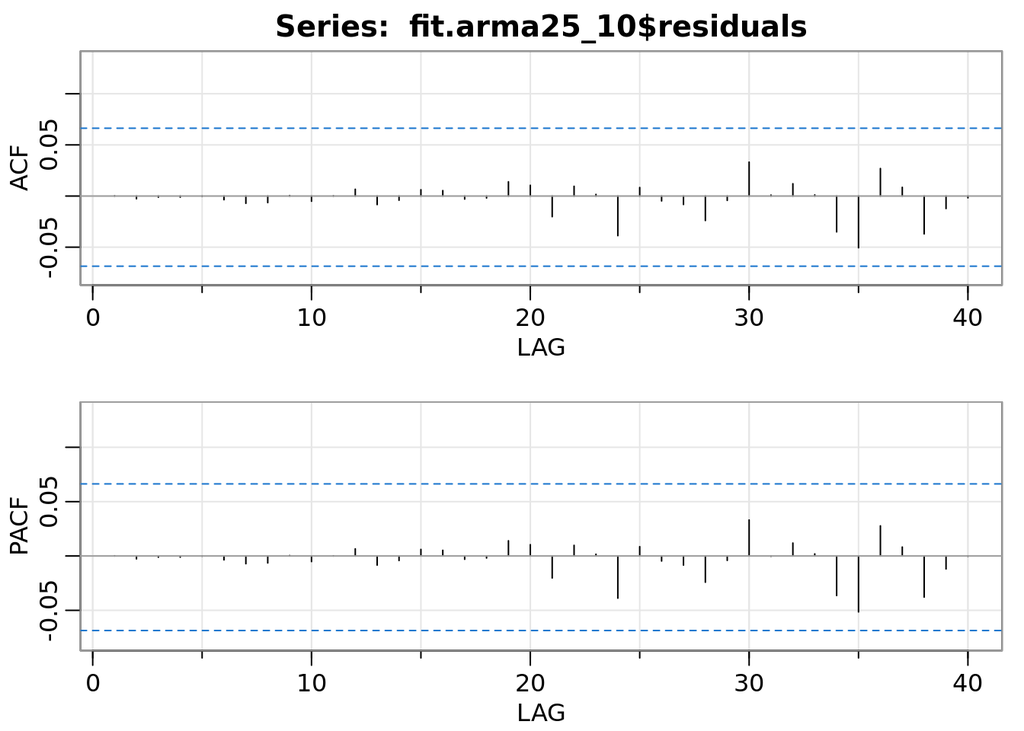

```r
acf24 = acf2(fit.arma25_9$residuals)
```

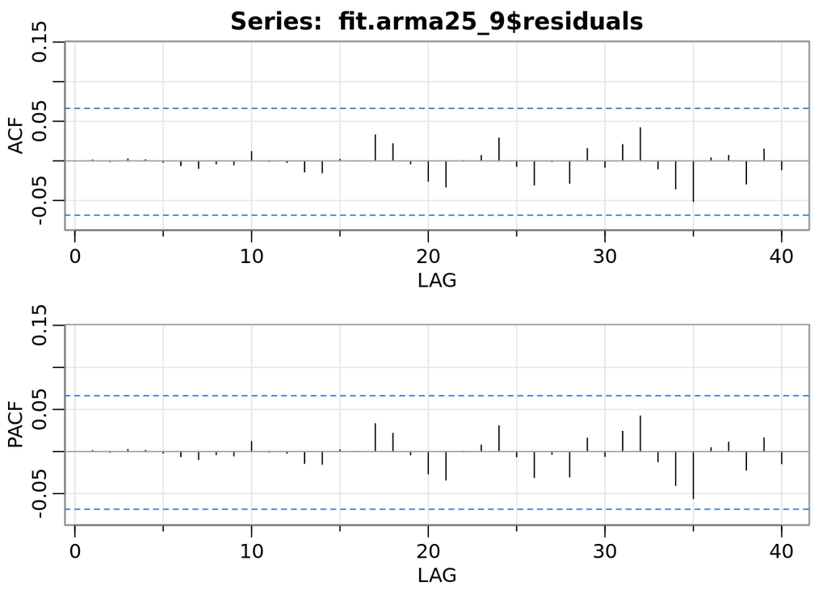

### Question 3

An ARMA(3, 0) model is fit to the following quarterly time series:

```r
frame <- data.frame(matrix(ncol=5, nrow=3))
colnames(frame) = c("Year", "Quarter 1", "Quarter 2", "Quarter 3", "Quarter 4")

frame$Year = c(2018, 2019, 2020)
frame$`Quarter 1`= c(3.53, 0.98, 2.91)
frame$`Quarter 2`= c(1.33, 3.61, 2.12)
frame$`Quarter 3`= c(1.85, 3.44, 4.62)
frame$`Quarter 4`= c(0.61, 3.38, 2.93)
frame
```

```
##   Year Quarter 1 Quarter 2 Quarter 3 Quarter 4
## 1 2018      3.53      1.33      1.85      0.61
## 2 2019      0.98      3.61      3.44      3.38
## 3 2020      2.91      2.12      4.62      2.93
```

```r
frame2 <- data.frame(matrix(ncol=4, nrow=1))
colnames(frame2) = c("ar1", "ar2", "ar3", "Intercept")
frame2[1,] = c(0.252, 0.061, -0.202, 2.637)
frame2
```

```
##     ar1   ar2    ar3 Intercept
## 1 0.252 0.061 -0.202     2.637
```

Forecast the value for Quarter 1 of 2021. Give full explanation on how you arrived to your answer. Show calculations.

A. Less that 3.00  
B. At least 3.00, but less than 3.25  
C. At least 3.25, but less than 3.50  
D. Atleast 3.50, but less than 3.75  
E. At least 3.75.  
Important: For models with AR part, the ”intercept” reported in standard output of R is a misnomer. It is actually the mean of the process, so that the fitted model is

X<sub>t</sub> − 2.637 = 0.252(X<sub>t−1</sub> − 2.637) + 0.061(X<sub>t−2</sub> − 2.637) − 0.202(X<sub>t−3</sub> − 2.637) + Z<sub>t</sub>.

### Question 4

You are given the following information about an AR(1) model with mean 0: ρ(2) = 0.215, ρ(3) = −0.100, X<sub>T</sub> = −0.431. Calculate the forecasted value of X <sub>T+1</sub>.
$$
$$\begin{aligned}
\text{For an AR(1) model, } \rho_k = \phi_1^k\\
\sqrt{0.215} = \pm 0.46368\\
(-0.100)^{1/3} = -0.46368\\
X_{t+1} = -0.46368 * -0.431\\
= 0.20
\end{aligned}$$

### Question 5

The five models, AR(1), ARMA(1, 1), ARMA(1, 2), ARMA(2, 3), and ARMA(4, 3) are fitted to the same time series. The models are ranked using Akaike Information Criterion (AIC): AIC = −2 × log-likelihood+2 ×(p + q + 2).  
You are given the following information:

```r
frame2 = data.frame(matrix(ncol=2, nrow=5))
colnames(frame2) = c("Model", "Loglikelihood")
frame2$Model=c("AR(1)", "ARMA(1,1)", "ARMA(1,2)", "ARMA(2,3)", "ARMA(4,3)")
frame2$Loglikelihood=c(-650, -641, -636, -630, -629)
frame2
```

```
##       Model Loglikelihood
## 1     AR(1)          -650
## 2 ARMA(1,1)          -641
## 3 ARMA(1,2)          -636
## 4 ARMA(2,3)          -630
## 5 ARMA(4,3)          -629
```

*The following problems are for students enrolled in PSTAT 274 ONLY*

### Question G1

Suppose that in a sample of size 100, we obtain $\hat{ρ}$(1) = 0.438 and $\hat{ρ}$(2) = 0.145. Assuming that the data were generated from an MA(1) model, construct approximate 95% confidence intervals for both ρ(1) and ρ(2). Based on these two confidence intervals, are the data consistent with an MA(1) model with θ = 0.6? Help: (i) Bartlett’s formula, was discussed in §10.3, slides 52, 55 and 56, of week 4. It gives distribution of sample acfs: For h is approximately N(ρ,n−1W) with the elements of matrix W computed by Bartelett’s formula: ∞ large sample size n, ρˆwij =X{ρ(k+i)+ρ(k−i)−2ρ(i)ρ(k)}×{ρ(k+j)+ρ(k−j)−2ρ(j)ρ(k)} (ii) The acf of MA(1) model was calculated in §3.2, week 1, see slide 64. (iii) To write confidence intervals for ρ(1) and ρ(2) you need to compute wii for i = 1,2 from Bartlett’s formula. For example, for MA(1) one gets w11 = 1 − 3ρ(1)2 + 4ρ(1)4. Recall that wii = 1 + 2ρ(1)2 for i > 1 (Why?).